# A2: on Own

Havisha Khurana

2025-02-04

## Task

**Part 1.** Stay small, but… work up something on your own that demonstrates something through the use of a simulation:a repeated-iterations simulation, yes. I would really like you to come up with something on your own, but a good example of a puzzle-y little environment could be this:

*In this assignment, I am exploring how the point-estimate and the standard error estimates change if there is more variation in the treatment group than the control group. To test for change, I have specified 4 condition for treatment group variation (while keeping the DGP variance similar) and 3 condition for the sample size. I ran 200 iteration for each combination.*

## **The DGP:**

```r
library(tidyverse)
library(broom)
library(janitor)
library(ggridges)
```

I want a DGP where the treated group has more variation that control group, keeping the overall DGP variation constant. To retain the total variance in DGP, use the relationship that -

$var_{n_1+n_2}^2 = \frac{(n_1-1)*var^2_{n_1} + (n_2 - 1)*var^2_{n_2}}{n_1 + n_2 - 2}$

*Priors:*

The estimate of beta will not change but the SE become larger as the variation in treatment groups (or one of the groups) become bigger compared to the other.

```r
get_var <- function(base_sd = 2, #measure of overall variance in the DGP
                    control_sd,
                    sample_n = 100) {
  # set equal control and treatment sizes
  control_n <- sample_n / 2
  treatment_n <- sample_n / 2

  # find treatment variance using formula
  treatment_var <- ((base_sd ^ 2) * (control_n + treatment_n - 2) -(control_n - 1) *control_sd ^ 2)/(treatment_n - 1)

  # take sqrt to get sd
  treatment_sd <- sqrt(treatment_var)

  # return sd
  return(treatment_sd)
}
```

```r
sample_size <- c(50, 100, 500)
control_sd <- c(2, 1.5, 1, 0.5)
iter <- 200
iter_matrix <- expand.grid(1:iter, control_sd, sample_size) %>%
  rename("seed" = "Var1",
         "control_sd" = "Var2",
         "sample_n" = "Var3") %>%
  rowwise() %>%
  mutate(treatment_sd = get_var(control_sd = control_sd, sample_n = sample_n)) %>%
  ungroup() %>%
  mutate(
    note = paste0("Treat SD = ", round(treatment_sd, 2))
  )

# list of dgps
dgp_diff_var_list <- pmap(list(iter_matrix$seed,
                          iter_matrix$control_sd,
                          iter_matrix$treatment_sd,
                          iter_matrix$sample_n), ~ {
  set.seed(..1)

  tibble(
  # first half people get treatment and other half don't
  t = c(rep(1, ..4/2), rep(0, ..4/2)),
  # random error
  e = rnorm(n = ..4, sd = 0.5),
  # if y would have got treatment, then it's outcome from the distribution with more variance
  y_treat = rnorm(n = ..4, sd = ..3),
  # if y were in control, it's outcome from a distribution with less variance
  y_control = rnorm(n = ..4, sd = ..2),

  # making y outcome
  y = ifelse(t == 1, y_treat + 1 + e, y_control + e)
  )
}
)
```

**Part 2:** Informative visualizations?

There seems to be a difference in average outcome, especially across small sample size.

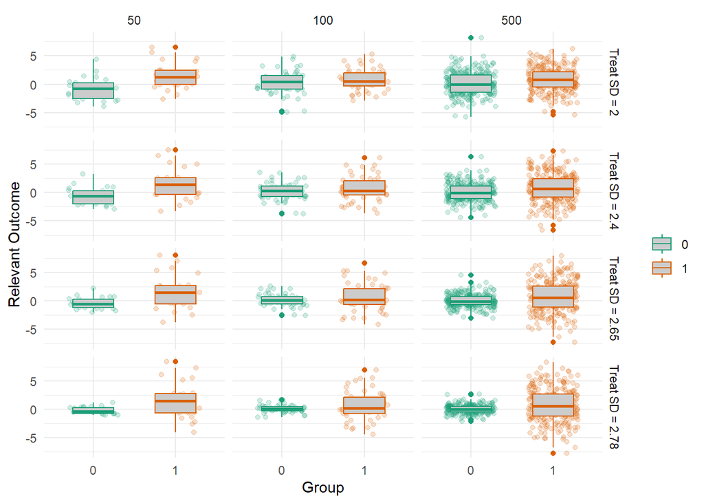

```r
# let's plot the data for a random seed across multiple conditions
df_seed1_index <- which(iter_matrix$seed == 1)
df_seed1 <- map_dfr(df_seed1_index, ~dgp_diff_var_list[[.x]] %>%
                      cbind(iter_matrix[.x,]))

df_seed1 %>%
  ggplot(aes(x = factor(t), y = y, color = factor(t))) +
  geom_jitter(alpha = 0.2, width = 0.3) +
  geom_boxplot(width = 0.5, fill = "gray80")+
  facet_grid(note~factor(sample_n)) +
  scale_color_manual(
    values = RColorBrewer::brewer.pal(n = 2, "Dark2")
  ) +
  labs(
    x = "Group",
    y = "Relevant Outcome",
    color = ""
  ) +
  theme_minimal()
```

## **Verify DGPs have the similar variance**

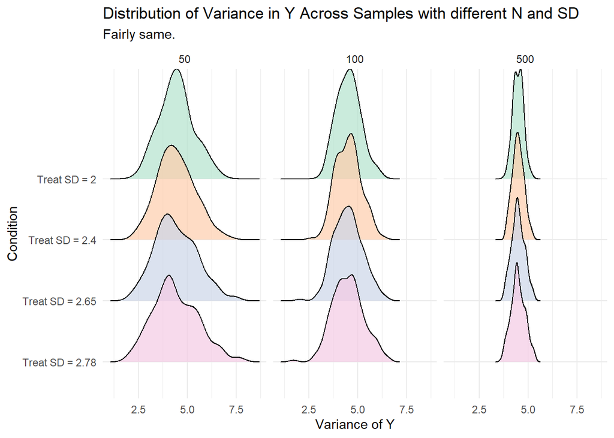

```r
iter_matrix$dgp_var <- map_dbl(dgp_diff_var_list, ~var(.x$y))

ggplot(data = iter_matrix,
       aes(x = dgp_var, y = fct_rev(note), fill = note)) +
  geom_density_ridges(alpha = 0.7, show.legend = F) +
  facet_wrap(~factor(sample_n))+
  #scale_y_discrete(labels = str_wrap(unique(iter_matrix$note), 15)) +
  theme_minimal() +
  labs(
    x = "Variance of Y",
    y = "Condition",
    title = "Distribution of Variance in Y Across Samples with different N and SD",
    subtitle = "Fairly same."
  ) +
  scale_fill_manual(
    values = RColorBrewer::brewer.pal(4, "Pastel2")
  )
```

**Part 3:** Simulation results?

**The simulation:**

```r
iter_matrix <- iter_matrix %>%
  cbind(map_df(dgp_diff_var_list,
               ~lm(y ~ t, data = .x) %>%
                 tidy() %>%
                 filter(term == "t"))) %>%
  clean_names()
```

**Visualization of the result:**

```r
line_plot <- function(y_title, statistic){
 plot <- iter_matrix %>%
  group_by(note, sample_n) %>%
  summarize(
    mean = mean({{statistic}}),
    q2.5 = quantile({{statistic}}, 0.025),
    q97.5 = quantile({{statistic}}, 0.975),
    ) %>%
  ungroup() %>%
  ggplot(aes(x = factor(sample_n), color = note)) +
  #geom_hline(aes(yintercept = 1), linetype = "dashed", color = "black") +
  geom_errorbar(aes(ymin = q2.5, y = mean, ymax = q97.5), width = 0.2,
                position = position_dodge(width = 0.5)) +
  geom_point(aes(y = mean), size = 2,
              position = position_dodge(width = 0.5)) +
  labs(
    x = "Sample size",
    y = y_title,
    color = "",
    caption = "Error bars represents 95% of the y-distribution across samples."
  ) +
  theme_minimal() +
  scale_color_manual(
    values = RColorBrewer::brewer.pal(4, "Dark2")
  )

 return(plot)
}
```

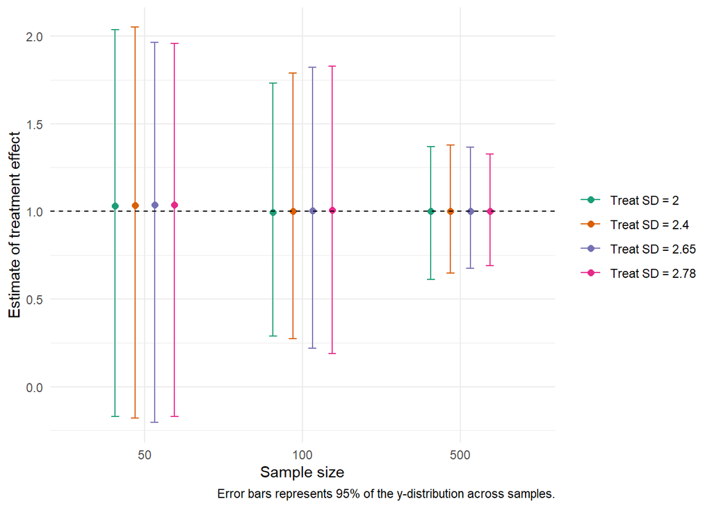

```r
line_plot(y_title = "Estimate of treatment effect",
          estimate) +
  geom_hline(aes(yintercept = 1),
             linetype = "dashed",
             color = "black")
```

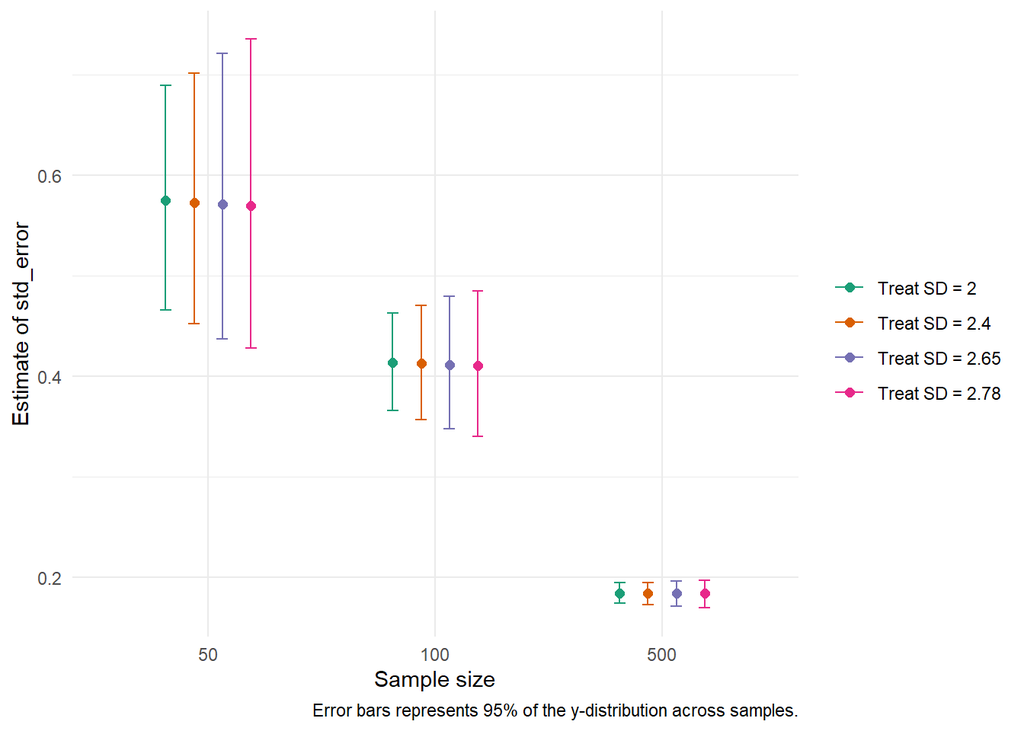

```r
line_plot(y_title = "Estimate of std_error",
          std_error)
```

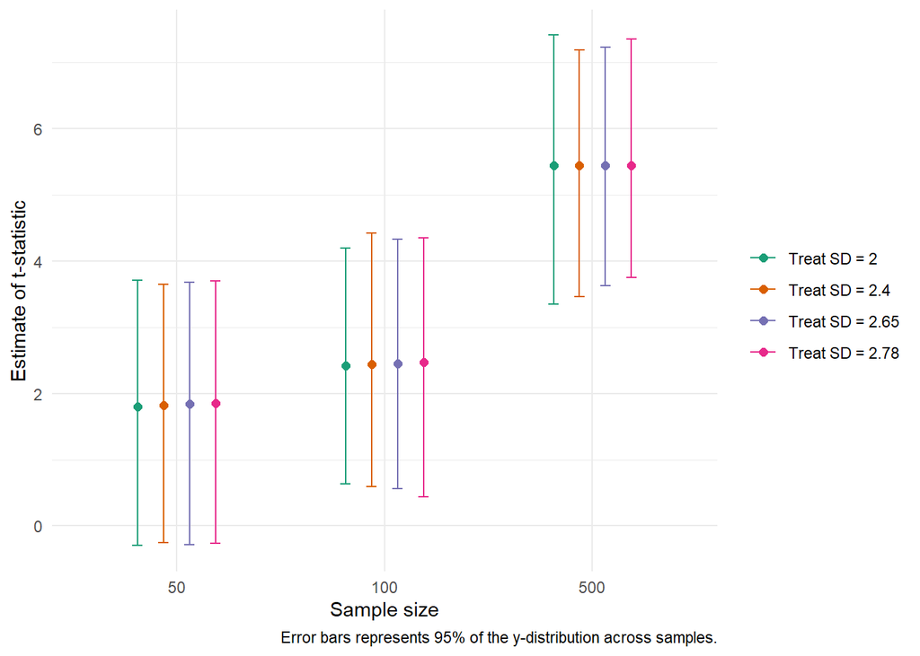

```r
line_plot(y_title = "Estimate of t-statistic",
          statistic)
```

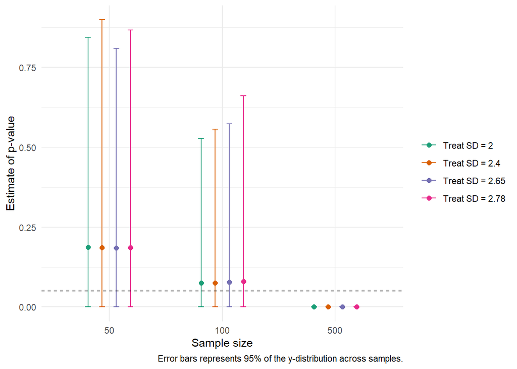

```r
line_plot(y_title = "Estimate of p-value",
          p_value) +
  geom_hline(aes(yintercept = 0.05),
             linetype = "dashed",
             color = "black")
```